# Cyclistic Bike Share Analysis

Emanuel Fisha Molla

2024-12-26

## Introduction

In this analysis, I explore the bike-sharing dataset to identify key trends and insights. This report is based on the data collected from Cyclistic, a bike-sharing program, which will help us understand how riders use the service.

## Problem Statement and Objective

The primary objective of this analysis is to determine how different types of users (e.g., casual vs. annual members) utilize the bike-sharing service. Specifically, we aim to answer the following questions:

- What is the distribution of rides by type of user?
- How do ride durations differ between casual and annual members?
- What time patterns can be observed in the bike usage?

## Data Frame Overview

The dataset contains information about each ride, including the start and end times, user type, and bike usage details.

```r
table_info
```

Column Names and Data Types

|  | Data_Type |
| --- | --- |
| ride_id | character |
| started_at | character |
| ended_at | character |
| rideable_type | character |
| start_station_id | integer |
| start_station_name | character |
| end_station_id | integer |
| end_station_name | character |
| member_casual | character |
| date | character |
| month | integer |
| day | integer |
| year | integer |
| day_of_week | character |
| ride_length | integer |

## Exploratory Data Analysis (EDA)

Now, let’s explore the dataset to understand the key features and patterns.

#### User Type Distribution

We’ll start by analyzing the distribution of users.

```r
user_type_count
```

| User_type | num_rides |
| --- | --- |
| casual | 67877 |
| member | 720312 |

#### Ride Duration Analysis

Next, we analyze the ride durations for each user type.

```r
duration_summary
```

| User_type | Average_ride_length |
| --- | --- |
| casual | 5370.7685 |
| member | 795.1324 |

## Data Visualizations

We now visualize the key findings using graphs.

#### Distribution of Rides by User Type

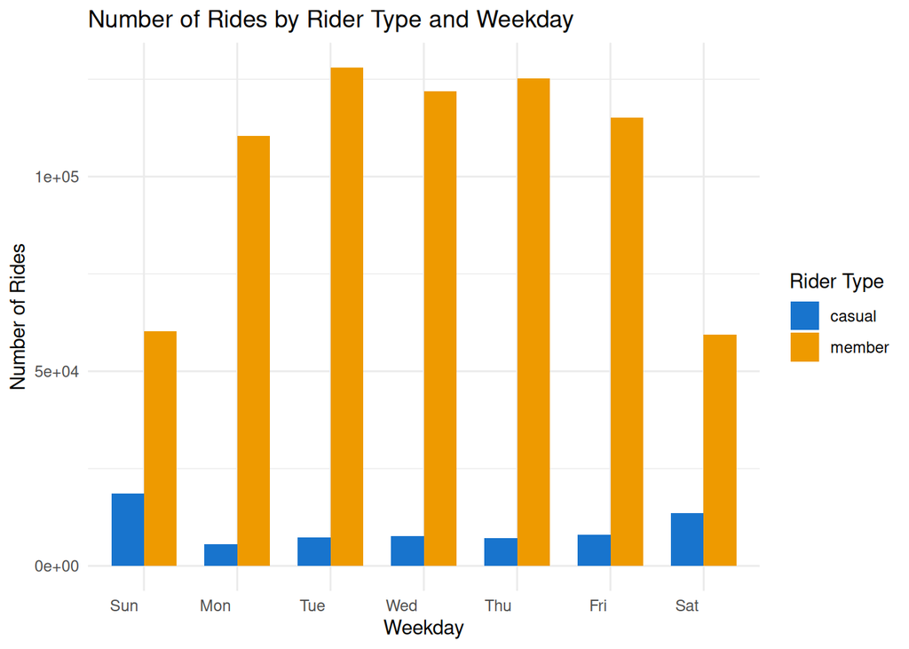

```r
num_rides_viz
```

#### Ride Duration Comparison

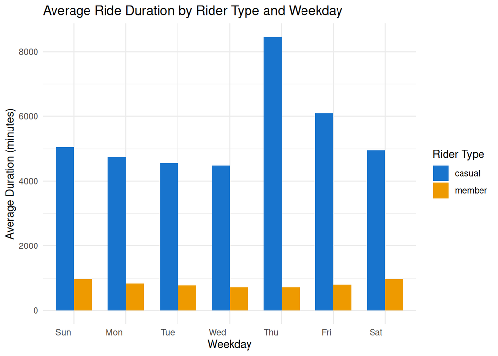

```r
ride_dur_viz
```

## Conclusion and Recommendations

In this analysis, we observed significant differences between annual members and casual riders:

- Annual members have a higher number of rides, but their rides tend to be shorter on average.
- Casual riders tend to take longer rides but are less frequent in their usage.

### Business Recommendations:

1. Targeting Casual Riders for Conversion: Casual riders could greatly benefit from an annual membership. Although they tend to take longer trips, they are not using the service as frequently. By converting them to annual members, they would enjoy unlimited rides at no additional cost per ride, which might encourage them to use the service more often, especially for longer trips.
2. Using Digital Media: Digital campaigns, including social media ads and email promotions, could highlight these benefits, especially targeting those who already show interest in regular bike usage. Promoting the convenience and cost-saving aspects of the annual membership could appeal to casual riders.
3. Maximizing Member Conversion: By offering promotions, discounts, or trial memberships, Cyclistic can encourage casual riders to become long-term members.